# Data Project - Stock price prediction

Dữ liệu chuỗi thời gian là một chuỗi các điểm dữ liệu được lập chỉ mục theo thứ tự thời gian. Dữ liệu chuỗi thời gian ở khắp mọi nơi, vì vậy việc thao tác với chúng rất quan trọng đối với bất kỳ nhà phân tích dữ liệu hoặc nhà khoa học dữ liệu nào.

Trong sổ ghi chép này, chúng ta sẽ khám phá và khám phá dữ liệu từ thị trường chứng khoán, đặc biệt là một số cổ phiếu công nghệ (Apple, Amazon, Google và Microsoft). Chúng ta sẽ tìm hiểu cách sử dụng yfinance để lấy thông tin chứng khoán và trực quan hóa các khía cạnh khác nhau của nó bằng Seaborn và Matplotlib. chúng ta sẽ xem xét một số cách phân tích rủi ro của một cổ phiếu, dựa trên lịch sử hoạt động trước đó của nó. Chúng tôi cũng sẽ dự đoán giá cổ phiếu trong tương lai thông qua phương pháp Bộ nhớ dài hạn ngắn hạn (LSTM)!

Chúng tôi sẽ trả lời các câu hỏi sau trên đường đi:

```
 1.) Giá cổ phiếu thay đổi như thế nào theo thời gian?
 2.) Lợi nhuận trung bình hàng ngày của cổ phiếu là bao nhiêu?
 3.) Đường trung bình động của các cổ phiếu khác nhau là bao nhiêu?
 4.) Mối tương quan giữa các cổ phiếu khác nhau là gì?
 5.) Chúng ta mạo hiểm bao nhiêu giá trị khi đầu tư vào một cổ phiếu cụ thể?
 6.) Làm thế nào chúng ta có thể cố gắng dự đoán hành vi chứng khoán trong tương lai? (Dự đoán giá cổ phiếu đóng cửa của APPLE inc sử dụng LSTM)
```

## Lấy dữ liệu

Bước đầu tiên là lấy dữ liệu và tải nó vào bộ nhớ. Chúng tôi sẽ lấy dữ liệu chứng khoán từ trang web Yahoo Finance. Yahoo Finance là nguồn tài nguyên phong phú về dữ liệu thị trường tài chính và các công cụ để tìm các khoản đầu tư hấp dẫn. Để lấy dữ liệu từ Yahoo Finance, chúng tôi sẽ sử dụng thư viện yfinance cung cấp một cách theo luồng và Pythonic để tải xuống dữ liệu thị trường từ Yahoo. Hãy xem bài viết này để tìm hiểu thêm về yfinance: [Tải xuống dữ liệu lịch sử thị trường một cách đáng tin cậy bằng Python](https://aroussi.com/post/python-yahoo-finance)

# 1. Giá cổ phiếu thay đổi theo thời gian như thế nào?

Trong phần này, chúng ta sẽ xem xét cách xử lý yêu cầu thông tin chứng khoán với gấu trúc và cách phân tích các thuộc tính cơ bản của chứng khoán.

```python
!pip install -q yfinance
```

[output not shown]

```python
import pandas as pd
import numpy as np

import matplotlib.pyplot as plt
import seaborn as sns
sns.set_style('whitegrid')
plt.style.use("fivethirtyeight")
%matplotlib inline

# Lấy dữ liệu chứng khoán từ yfinance
from pandas_datareader.data import DataReader
import yfinance as yf
from pandas_datareader import data as pdr

yf.pdr_override()


from datetime import datetime


# Các loại cổ phiếu sẽ phân tích
tech_list = ['AAPL', 'GOOG', 'MSFT', 'AMZN']

# Thiết lập khoảng thời gian để lấy dữ liệu
tech_list = ['AAPL', 'GOOG', 'MSFT', 'AMZN']

end = datetime.now()
start = datetime(end.year - 1, end.month, end.day)

for stock in tech_list:
    globals()[stock] = yf.download(stock, start, end)


company_list = [AAPL, GOOG, MSFT, AMZN]
company_name = ["APPLE", "GOOGLE", "MICROSOFT", "AMAZON"]

for company, com_name in zip(company_list, company_name):
    company["company_name"] = com_name

df = pd.concat(company_list, axis=0)
df.tail(10)
```

```
[*********************100%***********************]  1 of 1 completed
[*********************100%***********************]  1 of 1 completed
[*********************100%***********************]  1 of 1 completed
[*********************100%***********************]  1 of 1 completed
```

| Date | Open | High | Low | Close | Adj Close | Volume | company_name |
| --- | --- | --- | --- | --- | --- | --- | --- |
| 2023-06-22 | 125.309998 | 130.330002 | 125.139999 | 130.149994 | 130.149994 | 90354600 | AMAZON |
| 2023-06-23 | 129.110001 | 130.839996 | 128.279999 | 129.330002 | 129.330002 | 71855200 | AMAZON |
| 2023-06-26 | 129.330002 | 131.490005 | 127.099998 | 127.330002 | 127.330002 | 59989300 | AMAZON |
| 2023-06-27 | 128.630005 | 130.089996 | 127.550003 | 129.179993 | 129.179993 | 46801000 | AMAZON |
| 2023-06-28 | 128.940002 | 131.479996 | 128.440002 | 129.039993 | 129.039993 | 52149500 | AMAZON |
| 2023-06-29 | 128.770004 | 129.259995 | 127.260002 | 127.900002 | 127.900002 | 40761000 | AMAZON |
| 2023-06-30 | 129.470001 | 131.250000 | 128.949997 | 130.360001 | 130.360001 | 54310500 | AMAZON |
| 2023-07-03 | 130.820007 | 131.850006 | 130.070007 | 130.220001 | 130.220001 | 28264800 | AMAZON |
| 2023-07-05 | 130.240005 | 131.399994 | 129.639999 | 130.380005 | 130.380005 | 35895400 | AMAZON |
| 2023-07-06 | 128.250000 | 128.729996 | 127.370003 | 128.360001 | 128.360001 | 40639900 | AMAZON |

```python
df.info
```

```
<bound method DataFrame.info of                   Open        High         Low       Close   Adj Close  \
Date
2022-07-07  143.289993  146.550003  143.279999  146.350006  145.481293
2022-07-08  145.259995  147.550003  145.000000  147.039993  146.167206
2022-07-11  145.669998  146.639999  143.779999  144.869995  144.010086
2022-07-12  145.759995  148.449997  145.050003  145.860001  144.994202
2022-07-13  142.990005  146.449997  142.119995  145.490005  144.626404
...                ...         ...         ...         ...         ...
2023-06-29  128.770004  129.259995  127.260002  127.900002  127.900002
2023-06-30  129.470001  131.250000  128.949997  130.360001  130.360001
2023-07-03  130.820007  131.850006  130.070007  130.220001  130.220001
2023-07-05  130.240005  131.399994  129.639999  130.380005  130.380005
2023-07-06  128.250000  128.729996  127.370003  128.360001  128.360001

              Volume company_name
Date
2022-07-07  66253700        APPLE
2022-07-08  64547800        APPLE
2022-07-11  63141600        APPLE
2022-07-12  77588800        APPLE
2022-07-13  71185600        APPLE
...              ...          ...
2023-06-29  40761000       AMAZON
2023-06-30  54310500       AMAZON
2023-07-03  28264800       AMAZON
2023-07-05  35895400       AMAZON
2023-07-06  40639900       AMAZON

[1004 rows x 7 columns]>
```

**Lưu ý nhanh:** Sử dụng `globals()` là cách đặt tên `DataFrame` cẩu thả, nhưng nó đơn giản. Bây giờ chúng ta có dữ liệu của mình, hãy thực hiện một số phân tích dữ liệu cơ bản và kiểm tra dữ liệu của chúng tôi.

## Thống kê mô tả về dữ liệu

`.describe()` tạo số liệu thống kê mô tả. Thống kê mô tả bao gồm những thống kê tóm tắt xu hướng trung tâm, độ phân tán và hình dạng phân phối của tập dữ liệu, ngoại trừ các giá trị `NaN`.

Phân tích cả chuỗi số và chuỗi đối tượng, cũng như tập hợp cột `DataFrame` của các loại dữ liệu hỗn hợp. Đầu ra sẽ khác nhau tùy thuộc vào những gì được cung cấp. Tham khảo các ghi chú dưới đây để biết thêm chi tiết.

```python
# Tóm tắt thống kê
AAPL.describe()
```

|  | Open | High | Low | Close | Adj Close | Volume |
| --- | --- | --- | --- | --- | --- | --- |
| count | 251.000000 | 251.000000 | 251.000000 | 251.000000 | 251.000000 | 2.510000e+02 |
| mean | 152.117251 | 154.227052 | 150.098406 | 152.240797 | 151.861737 | 8.545738e+07 |
| std | 13.239204 | 13.124055 | 13.268053 | 13.255593 | 13.057870 | 2.257398e+07 |
| min | 126.010002 | 127.769997 | 124.169998 | 125.019997 | 125.019997 | 3.519590e+07 |
| 25% | 142.110001 | 143.854996 | 139.949997 | 142.464996 | 142.190201 | 7.027710e+07 |
| 50% | 150.089996 | 151.990005 | 148.199997 | 150.649994 | 150.400497 | 8.100050e+07 |
| 75% | 163.434998 | 165.835007 | 160.879997 | 163.629997 | 163.200417 | 9.374540e+07 |
| max | 178.550003 | 179.610001 | 176.699997 | 178.960007 | 178.154037 | 1.826020e+08 |

## Thông tin về dữ liệu

Phương thức .info() in thông tin về DataFrame bao gồm chỉ mục dtype và cột, giá trị khác null và mức sử dụng bộ nhớ.

```python
# General info
AAPL.info()
AAPL.head()
```

[output not shown]

## Giá đóng cửa

Giá đóng cửa là giá cuối cùng mà cổ phiếu được giao dịch trong ngày giao dịch thông thường. Giá đóng cửa của cổ phiếu là điểm chuẩn được các nhà đầu tư sử dụng để theo dõi hiệu suất của nó theo thời gian.

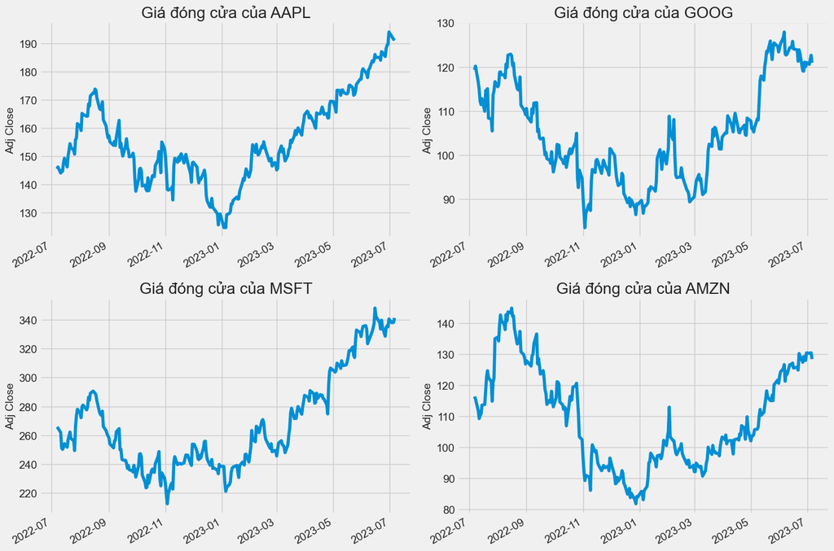

```python
# Hãy xem một cái nhìn lịch sử về giá đóng cửa
plt.figure(figsize=(15, 10))
plt.subplots_adjust(top=1.25, bottom=1.2)

for i, company in enumerate(company_list, 1):
    plt.subplot(2, 2, i)
    company['Adj Close'].plot()
    plt.ylabel('Adj Close')
    plt.xlabel(None)
    plt.title(f"Giá đóng cửa của {tech_list[i - 1]}")

plt.tight_layout()
```

## Khối lượng bán hàng

Khối lượng là số lượng tài sản hoặc chứng khoán thay đổi trong một khoảng thời gian, thường là trong một ngày. Chẳng hạn, khối lượng giao dịch chứng khoán sẽ đề cập đến số lượng cổ phiếu chứng khoán được giao dịch giữa thời điểm mở và đóng hàng ngày. Khối lượng giao dịch và những thay đổi về khối lượng theo thời gian là những yếu tố đầu vào quan trọng đối với các nhà giao dịch kỹ thuật.

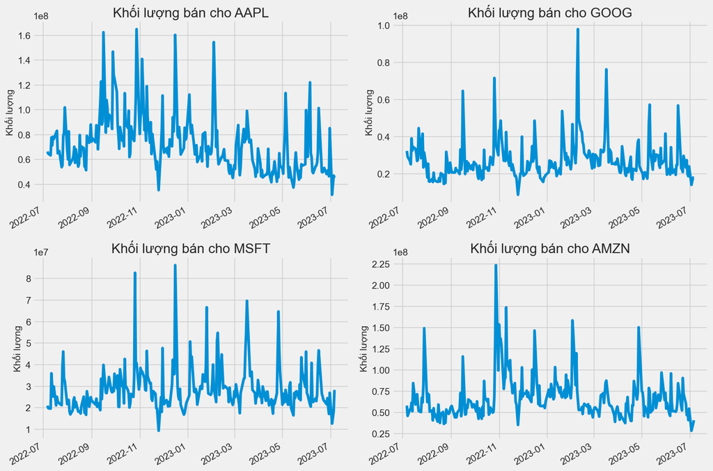

```python
# Bây giờ hãy vẽ tổng khối lượng cổ phiếu được giao dịch mỗi ngày
plt.figure(figsize=(15, 10))
plt.subplots_adjust(top=1.25, bottom=1.2)

for i, company in enumerate(company_list, 1):
    plt.subplot(2, 2, i)
    company['Volume'].plot()
    plt.ylabel('Khối lượng')
    plt.xlabel(None)
    plt.title(f"Khối lượng bán cho {tech_list[i - 1]}")

plt.tight_layout()
```

Bây giờ chúng ta đã thấy các hình ảnh trực quan về giá đóng cửa và khối lượng giao dịch mỗi ngày, hãy tiếp tục và tính toán đường trung bình động cho cổ phiếu.

# 2. Đường trung bình động của các cổ phiếu khác nhau là bao nhiêu?

Đường trung bình động (MA) là một công cụ phân tích kỹ thuật đơn giản giúp làm mịn dữ liệu giá bằng cách tạo ra một mức giá trung bình được cập nhật liên tục. Mức trung bình được lấy trong một khoảng thời gian cụ thể, chẳng hạn như 10 ngày, 20 phút, 30 tuần hoặc bất kỳ khoảng thời gian nào mà nhà giao dịch chọn.

** lưu ý : Giá đóng cửa điều chỉnh(adj close) là giá đóng cửa của cổ phiếu được điều chỉnh để phản ánh chính xác giá trị của cổ phiếu đó sau khi hạch toán cho bất kì hành động nào của công ty.

Giá đóng cửa điều chỉnh được coi là giá thực sự của cổ phiếu đó và thường được sử dụng khi kiểm tra lợi nhuận dựa trên dữ liệu quá khứ (Historical return) hoặc thực hiện phân tích chi tiết về lợi nhuận trong quá khứ.

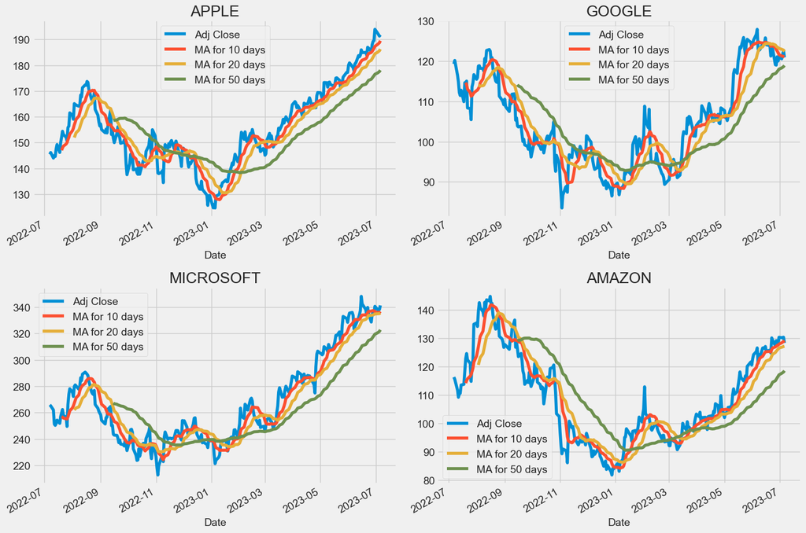

```python
ma_day = [10, 20, 50]

for ma in ma_day:
    for company in company_list:
        column_name = f"MA for {ma} days"
        company[column_name] = company['Adj Close'].rolling(ma).mean()


fig, axes = plt.subplots(nrows=2, ncols=2)
fig.set_figheight(10)
fig.set_figwidth(15)

AAPL[['Adj Close', 'MA for 10 days', 'MA for 20 days', 'MA for 50 days']].plot(ax=axes[0,0])
axes[0,0].set_title('APPLE')

GOOG[['Adj Close', 'MA for 10 days', 'MA for 20 days', 'MA for 50 days']].plot(ax=axes[0,1])
axes[0,1].set_title('GOOGLE')

MSFT[['Adj Close', 'MA for 10 days', 'MA for 20 days', 'MA for 50 days']].plot(ax=axes[1,0])
axes[1,0].set_title('MICROSOFT')

AMZN[['Adj Close', 'MA for 10 days', 'MA for 20 days', 'MA for 50 days']].plot(ax=axes[1,1])
axes[1,1].set_title('AMAZON')

fig.tight_layout()
```

## Chúng ta thấy trong biểu đồ rằng các giá trị tốt nhất để đo đường trung bình động là 10 và 20 ngày vì chúng vẫn nắm bắt xu hướng trong dữ liệu mà không bị nhiễu. so với đường trung bình động(MA) 50 ngày

# 3.Lợi nhuận trung bình hàng ngày của cổ phiếu là bao nhiêu?

### Bây giờ chúng ta đã thực hiện một số phân tích cơ bản, hãy tiếp tục và tìm hiểu sâu hơn một chút. Bây giờ chúng ta sẽ phân tích rủi ro của cổ phiếu. Để làm như vậy, chúng ta cần xem xét kỹ hơn những thay đổi hàng ngày của cổ phiếu chứ không chỉ giá trị tuyệt đối của nó. Hãy tiếp tục và sử dụng gấu trúc để lấy lợi tức hàng ngày cho cổ phiếu Apple.

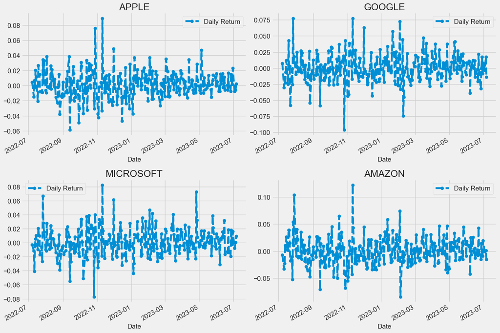

```python
# Chúng ta sẽ sử dụng pct_change để tìm phần trăm thay đổi cho mỗi ngày
for company in company_list:
    company['Daily Return'] = company['Adj Close'].pct_change()

# Sau đó, chúng ta sẽ vẽ biểu đồ tỷ lệ hoàn vốn hàng ngày
fig, axes = plt.subplots(nrows=2, ncols=2)
fig.set_figheight(10)
fig.set_figwidth(15)

AAPL['Daily Return'].plot(ax=axes[0,0], legend=True, linestyle='--', marker='o')
axes[0,0].set_title('APPLE')

GOOG['Daily Return'].plot(ax=axes[0,1], legend=True, linestyle='--', marker='o')
axes[0,1].set_title('GOOGLE')

MSFT['Daily Return'].plot(ax=axes[1,0], legend=True, linestyle='--', marker='o')
axes[1,0].set_title('MICROSOFT')

AMZN['Daily Return'].plot(ax=axes[1,1], legend=True, linestyle='--', marker='o')
axes[1,1].set_title('AMAZON')

fig.tight_layout()
```

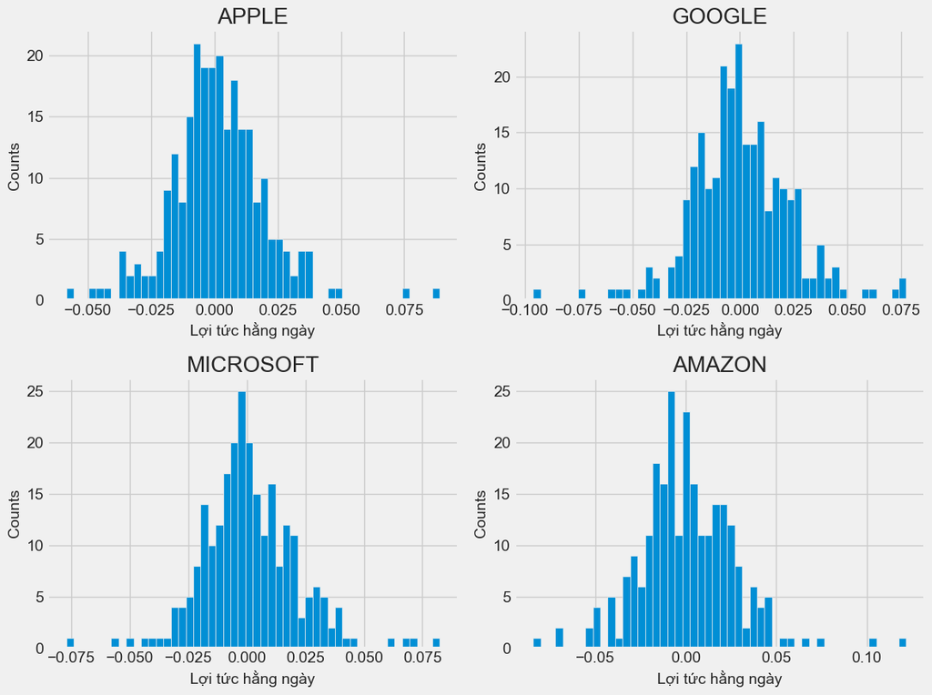

```python
plt.figure(figsize=(12, 9))

for i, company in enumerate(company_list, 1):
    plt.subplot(2, 2, i)
    company['Daily Return'].hist(bins=50)
    plt.xlabel('Lợi tức hằng ngày')
    plt.ylabel('Counts')
    plt.title(f'{company_name[i - 1]}')

plt.tight_layout()
```

# 4. Mối tương quan giữa giá đóng cửa của các cổ phiếu khác nhau là gì?

Tương quan là một thống kê đo lường mức độ di chuyển của hai biến trong mối quan hệ với nhau có giá trị phải nằm trong khoảng từ -1,0 đến +1,0. Mối tương quan đo lường sự liên kết, nhưng không hiển thị nếu x gây ra y hoặc ngược lại — hoặc liệu sự liên kết có phải do yếu tố thứ ba gây ra hay không[1].

Bây giờ, nếu chúng ta muốn phân tích lợi nhuận của tất cả các cổ phiếu trong danh sách thì sao? Hãy tiếp tục và xây dựng một Khung dữ liệu với tất cả các cột ['close'] cho từng khung dữ liệu cổ phiếu.

```python
# Lấy tất cả giá đóng cửa cho danh sách cổ phiếu công nghệ vào một Khung dữ liệu

closing_df = pdr.get_data_yahoo(tech_list, start=start, end=end)['Adj Close']

# Tạo một DataFrame trả về tech mới
tech_rets = closing_df.pct_change()
tech_rets.head()
```

```
[*********************100%***********************]  4 of 4 completed
```

| Date | AAPL | AMZN | GOOG | MSFT |
| --- | --- | --- | --- | --- |
| 2022-07-07 | NaN | NaN | NaN | NaN |
| 2022-07-08 | 0.004715 | -0.006791 | 0.007229 | -0.002757 |
| 2022-07-11 | -0.014758 | -0.032803 | -0.030341 | -0.011769 |
| 2022-07-12 | 0.006834 | -0.022640 | -0.014358 | -0.040981 |
| 2022-07-13 | -0.002537 | 0.010804 | -0.023183 | -0.003745 |

Bây giờ chúng ta có thể so sánh tỷ lệ phần trăm lợi nhuận hàng ngày của hai cổ phiếu để kiểm tra mức độ tương quan. Đầu tiên chúng ta hãy xem sotck so với chính nó.

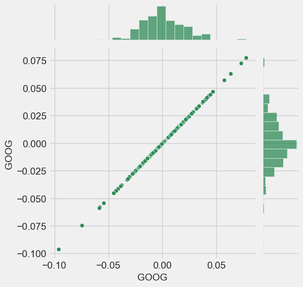

```python
# So sánh Google với chính nó sẽ hiển thị một mối quan hệ tuyến tính hoàn hảo
sns.jointplot(x='GOOG', y='GOOG', data=tech_rets, kind='scatter', color='seagreen');
```

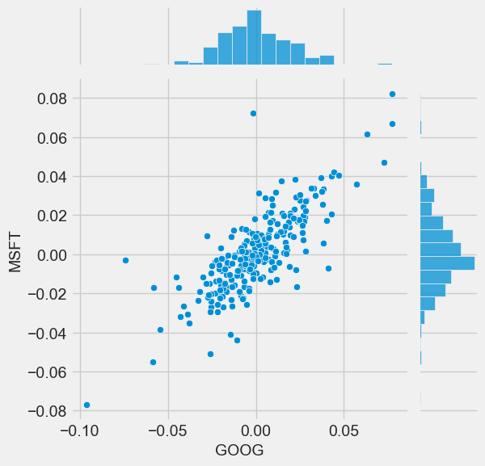

```python
# Chúng tôi sẽ sử dụng joinplot để so sánh lợi nhuận hàng ngày của Google và Microsoft
sns.jointplot(x='GOOG', y='MSFT', data=tech_rets, kind='scatter');
```

# 5. Chúng ta mạo hiểm bao nhiêu giá trị khi đầu tư vào một cổ phiếu cụ thể?

Có nhiều cách chúng ta có thể định lượng rủi ro, một trong những cách cơ bản nhất bằng cách sử dụng thông tin mà chúng ta đã thu thập về tỷ lệ phần trăm lợi nhuận hàng ngày là so sánh lợi tức kỳ vọng với độ lệch chuẩn của lợi tức hàng ngày.

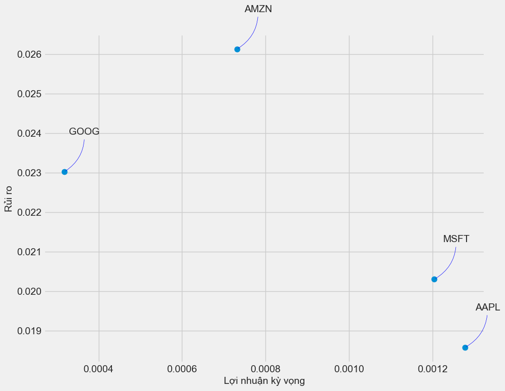

```python
rets = tech_rets.dropna()

area = np.pi * 20

plt.figure(figsize=(10, 8))
plt.scatter(rets.mean(), rets.std(), s=area)
plt.xlabel('Lợi nhuận kỳ vọng')
plt.ylabel('Rủi ro')

for label, x, y in zip(rets.columns, rets.mean(), rets.std()):
    plt.annotate(label, xy=(x, y), xytext=(50, 50), textcoords='offset points', ha='right', va='bottom',
                 arrowprops=dict(arrowstyle='-', color='blue', connectionstyle='arc3,rad=-0.3'));
```

# 6. Dự đoán giá đóng cửa cổ phiếu của APPLE inc:

```python
# Nhận báo giá cổ phiếu
df = pdr.get_data_yahoo('AAPL', start='2012-01-01', end=datetime.now())
# Hiển thị dữ liệu
df
```

```
[*********************100%***********************]  1 of 1 completed
```

| Date | Open | High | Low | Close | Adj Close | Volume |
| --- | --- | --- | --- | --- | --- | --- |
| 2012-01-03 | 14.621429 | 14.732143 | 14.607143 | 14.686786 | 12.482924 | 302220800 |
| 2012-01-04 | 14.642857 | 14.810000 | 14.617143 | 14.765714 | 12.550007 | 260022000 |
| 2012-01-05 | 14.819643 | 14.948214 | 14.738214 | 14.929643 | 12.689341 | 271269600 |
| 2012-01-06 | 14.991786 | 15.098214 | 14.972143 | 15.085714 | 12.821993 | 318292800 |
| 2012-01-09 | 15.196429 | 15.276786 | 15.048214 | 15.061786 | 12.801656 | 394024400 |
| ... | ... | ... | ... | ... | ... | ... |
| 2023-06-29 | 189.080002 | 190.070007 | 188.940002 | 189.589996 | 189.589996 | 46347300 |
| 2023-06-30 | 191.630005 | 194.479996 | 191.259995 | 193.970001 | 193.970001 | 85069600 |
| 2023-07-03 | 193.779999 | 193.880005 | 191.759995 | 192.460007 | 192.460007 | 31458200 |
| 2023-07-05 | 191.570007 | 192.979996 | 190.619995 | 191.330002 | 191.330002 | 46920300 |
| 2023-07-06 | 189.839996 | 192.020004 | 189.199997 | 191.809998 | 191.809998 | 45094300 |

2895 rows × 6 columns

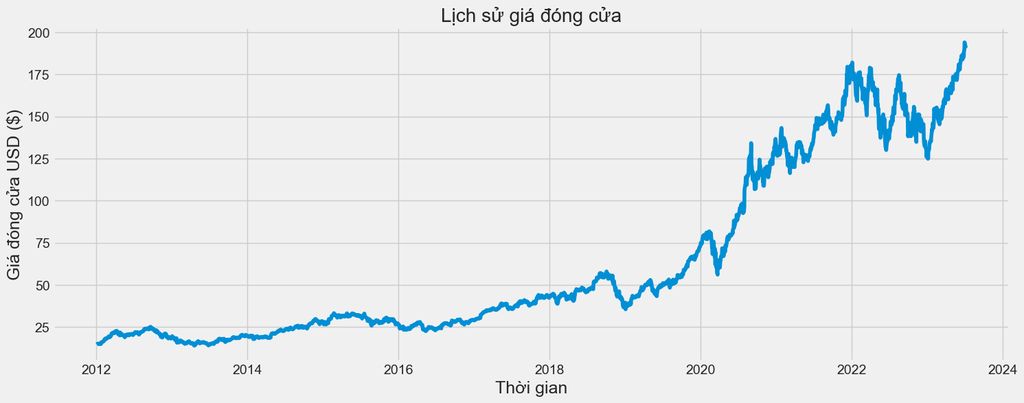

```python
plt.figure(figsize=(16,6))
plt.title('Lịch sử giá đóng cửa')
plt.plot(df['Close'])
plt.xlabel('Thời gian', fontsize=18)
plt.ylabel('Giá đóng cửa USD ($)', fontsize=18)
plt.show()
```

```python
# Tạo một khung dữ liệu mới chỉ với cột 'Đóng
data = df.filter(['Close'])
# Chuyển đổi khung dữ liệu thành một mảng có nhiều mảng
dataset = data.values
# Lấy số hàng để huấn luyện mô hình
training_data_len = int(np.ceil( len(dataset) * .95 ))

training_data_len
```

```
2751
```

```python
# Chia tỷ lệ dữ liệu
from sklearn.preprocessing import MinMaxScaler

scaler = MinMaxScaler(feature_range=(0,1))
scaled_data = scaler.fit_transform(dataset)

scaled_data
```

```
array([[0.00410663],
       [0.00454506],
       [0.00545566],
       ...,
       [0.99161219],
       [0.98533517],
       [0.98800148]])
```

```python
# Tạo tập dữ liệu huấn luyện
# Tạo tập dữ liệu đào tạo được chia tỷ lệ
train_data = scaled_data[0:int(training_data_len), :]
# Tách dữ liệu thành tập dữ liệu x_train và y_train
x_train = []
y_train = []

for i in range(60, len(train_data)):
    x_train.append(train_data[i-60:i, 0])
    y_train.append(train_data[i, 0])
    if i<= 61:
        print(x_train)
        print(y_train)
        print()

# Chuyển đổi x_train và y_train thành mảng có nhiều mảng
x_train, y_train = np.array(x_train), np.array(y_train)

# Định hình lại dữ liệu
x_train = np.reshape(x_train, (x_train.shape[0], x_train.shape[1], 1))
# x_train.shape
```

```
[array([0.00410663, 0.00454506, 0.00545566, 0.00632262, 0.0061897 ,
       0.00648927, 0.00635238, 0.00612225, 0.00580879, 0.00677891,
       0.00765381, 0.007384  , 0.005906  , 0.00731654, 0.00592783,
       0.01113551, 0.01073279, 0.01125851, 0.01239527, 0.01308368,
       0.01302615, 0.01281387, 0.01371852, 0.0145696 , 0.01553377,
       0.01709112, 0.02036253, 0.02041213, 0.02223333, 0.02359427,
       0.02125528, 0.02215596, 0.02213811, 0.02466359, 0.0243045 ,
       0.0249691 , 0.02616339, 0.026828  , 0.02874244, 0.0301371 ,
       0.03053983, 0.03068069, 0.02829607, 0.02772074, 0.02780605,
       0.03004784, 0.03067871, 0.0320337 , 0.03522774, 0.03948911,
       0.03869159, 0.03869357, 0.04177454, 0.04273871, 0.04205228,
       0.04142538, 0.04077268, 0.04294106, 0.04442897, 0.04505191])]
[0.043512415186967204]

[array([0.00410663, 0.00454506, 0.00545566, 0.00632262, 0.0061897 ,
       0.00648927, 0.00635238, 0.00612225, 0.00580879, 0.00677891,
       0.00765381, 0.007384  , 0.005906  , 0.00731654, 0.00592783,
       0.01113551, 0.01073279, 0.01125851, 0.01239527, 0.01308368,
       0.01302615, 0.01281387, 0.01371852, 0.0145696 , 0.01553377,
       0.01709112, 0.02036253, 0.02041213, 0.02223333, 0.02359427,
       0.02125528, 0.02215596, 0.02213811, 0.02466359, 0.0243045 ,
       0.0249691 , 0.02616339, 0.026828  , 0.02874244, 0.0301371 ,
       0.03053983, 0.03068069, 0.02829607, 0.02772074, 0.02780605,
       0.03004784, 0.03067871, 0.0320337 , 0.03522774, 0.03948911,
       0.03869159, 0.03869357, 0.04177454, 0.04273871, 0.04205228,
       0.04142538, 0.04077268, 0.04294106, 0.04442897, 0.04505191]), array([0.00454506, 0.00545566, 0.00632262, 0.0061897 , 0.00648927,
       0.00635238, 0.00612225, 0.00580879, 0.00677891, 0.00765381,
       0.007384  , 0.005906  , 0.00731654, 0.00592783, 0.01113551,
       0.01073279, 0.01125851, 0.01239527, 0.01308368, 0.01302615,
       0.01281387, 0.01371852, 0.0145696 , 0.01553377, 0.01709112,
       0.02036253, 0.02041213, 0.02223333, 0.02359427, 0.02125528,
       0.02215596, 0.02213811, 0.02466359, 0.0243045 , 0.0249691 ,
       0.02616339, 0.026828  , 0.02874244, 0.0301371 , 0.03053983,
       0.03068069, 0.02829607, 0.02772074, 0.02780605, 0.03004784,
       0.03067871, 0.0320337 , 0.03522774, 0.03948911, 0.03869159,
       0.03869357, 0.04177454, 0.04273871, 0.04205228, 0.04142538,
       0.04077268, 0.04294106, 0.04442897, 0.04505191, 0.04351242])]
[0.043512415186967204, 0.04146703946151174]
```

```python
from keras.models import Sequential
from keras.layers import Dense, LSTM

# Xây dựng mô hình LSTM
model = Sequential()
model.add(LSTM(128, return_sequences=True, input_shape= (x_train.shape[1], 1)))
model.add(LSTM(64, return_sequences=False))
model.add(Dense(25))
model.add(Dense(1))

# Biên dịch mô hình
model.compile(optimizer='adam', loss='mean_squared_error')

# Huấn luyện mô hình
model.fit(x_train, y_train, batch_size=1, epochs=1)
```

```
<keras.callbacks.History at 0x296fb694850>
```

```python
# Tạo tập dữ liệu thử nghiệm
# Tạo một mảng mới chứa các giá trị được chia tỷ lệ từ chỉ số 1543 đến 2002
test_data = scaled_data[training_data_len - 60: , :]
# Tạo bộ dữ liệu x_test và y_test
x_test = []
y_test = dataset[training_data_len:, :]
for i in range(60, len(test_data)):
    x_test.append(test_data[i-60:i, 0])

# Chuyển đổi dữ liệu thành một mảng có nhiều mảng
x_test = np.array(x_test)

# Reshape the data
x_test = np.reshape(x_test, (x_test.shape[0], x_test.shape[1], 1 ))

# Nhận các mô hình dự đoán giá trị giá
predictions = model.predict(x_test)
predictions = scaler.inverse_transform(predictions)

# Lấy lỗi bình phương trung bình gốc (RMSE)
rmse = np.sqrt(np.mean(((predictions - y_test) ** 2)))
rmse
```

```
3.176571961968151
```

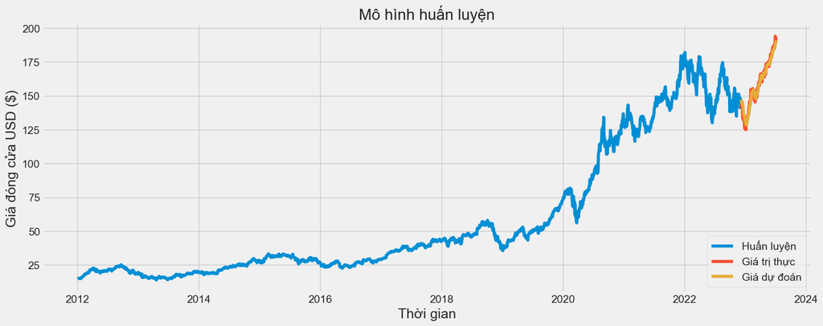

```python
# Vẽ đồ thị dữ liệu
train = data[:training_data_len]
valid = data[training_data_len:]
valid['Predictions'] = predictions
# Trực quan hóa dữ liệu
plt.figure(figsize=(16,6))
plt.title('Mô hình huấn luyện')
plt.xlabel('Thời gian', fontsize=18)
plt.ylabel('Giá đóng cửa USD ($)', fontsize=18)
plt.plot(train['Close'])
plt.plot(valid[['Close', 'Predictions']])
plt.legend(['Huấn luyện', 'Giá trị thực', 'Giá dự đoán'], loc='lower right')
plt.show();
```

```python
# Hiển thị giá hợp lệ và dự đoán
valid
```

| Date | Close | Predictions |
| --- | --- | --- |
| 2022-12-07 | 140.940002 | 147.200043 |
| 2022-12-08 | 142.649994 | 145.923538 |
| 2022-12-09 | 142.160004 | 145.027817 |
| 2022-12-12 | 144.490005 | 144.343826 |
| 2022-12-13 | 145.470001 | 144.351700 |
| ... | ... | ... |
| 2023-06-29 | 189.589996 | 186.880524 |
| 2023-06-30 | 193.970001 | 187.670547 |
| 2023-07-03 | 192.460007 | 189.202301 |
| 2023-07-05 | 191.330002 | 190.329422 |
| 2023-07-06 | 191.809998 | 190.862045 |

144 rows × 2 columns

# Tóm lại

Trong bài tìm hiểu AI dự đoán chứng khoán : chúng ta đã tìm hiểu được

- Cách tải dữ liệu thị trường chứng khoán từ trang web YAHOO Finance bằng yfinance.
- Cách khám phá và trực quan hóa dữ liệu chuỗi thời gian bằng Pandas, Matplotlib và Seaborn.
- Cách đo lường mối tương quan giữa các cổ phiếu.
- Làm thế nào để đo lường rủi ro khi đầu tư vào một cổ phiếu cụ thể.
- Dự đoán giá trị của 1 loại cổ phiếu